# A medida se sustenta? Validação contra um critério externo

Todo o resto deste pacote é tradução: um código do TSE vira um ISCO, que vira um ISEI. Nada nessa cadeia se afere contra coisa alguma **fora** dela — e um crosswalk internamente consistente pode estar inteiramente errado.

Esta vinheta faz a única pergunta que importa: as posições que a medida atribui correspondem a algo observável e independente?

O critério são duas variáveis que o próprio TSE coleta e que **não entram na construção da medida em momento nenhum**: o patrimônio declarado na candidatura e o grau de instrução. Elas estão agregadas por ocupação em `tse_validacao`.

```r
library(ocupacoesBR)

v <- tse_validacao
v$isei   <- isco88_para_isei(tse_isco$isco88[match(v$cod_tse, tse_isco$cod_tse)])
v$rotulo <- tse_para_rotulo(v$cod_tse)
v <- v[!is.na(v$isei), ]

# A mediana de patrimonio e NA onde faltam declaracoes de bens suficientes (ver
# ?tse_validacao). A escolaridade esta medida em todas as linhas; o patrimonio,
# so nestas.
vb <- v[!is.na(v$mediana_patrimonio), ]
c(com_escolaridade = nrow(v), com_patrimonio = nrow(vb))
```

```
#> com_escolaridade   com_patrimonio
#>              207              165
```

## O resultado

```r
r <- function(x, y, m = "pearson") round(cor(x, y, method = m), 3)

# A correlação no nível do INDIVÍDUO sai dos somatórios publicados em
# `tse_dispersao_patrimonio`, sem microdado: veja `?tse_dispersao_patrimonio`.
d <- tse_dispersao_patrimonio
N <- sum(d$n); sx <- sum(d$isei88 * d$n); sy <- sum(d$soma_log)
sxx <- sum(d$isei88^2 * d$n); syy <- sum(d$soma_log2)
sxy <- sum(d$isei88 * d$soma_log)
r_individual <- (N * sxy - sx * sy) / sqrt((N * sxx - sx^2) * (N * syy - sy^2))

data.frame(
  criterio = c("% com ensino superior", "log da mediana de patrimonio"),
  n        = c(nrow(v), nrow(vb)),
  pearson  = c(r(v$isei, v$pct_superior),
               r(vb$isei, log(vb$mediana_patrimonio))),
  spearman = c(r(v$isei, v$pct_superior, "spearman"),
               r(vb$isei, log(vb$mediana_patrimonio), "spearman")))
```

```
#>                       criterio   n pearson spearman
#> 1        % com ensino superior 207   0.765    0.816
#> 2 log da mediana de patrimonio 165   0.681    0.695
```

Correlações dessa ordem, contra critérios que não participaram da construção da medida, são evidência forte de que o ISEI atribuído às ocupações brasileiras mede o que promete medir.

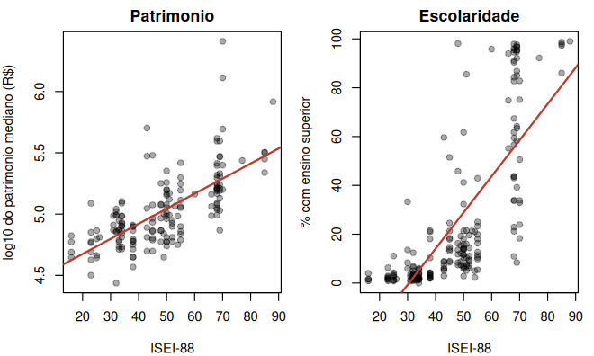

## O contraste que é o verdadeiro resultado

No nível da **candidatura**, a correlação entre ISEI e patrimônio é de apenas 0,207. No nível da **ocupação**, é 0,681. Essa diferença não é defeito: é a definição do que o ISEI é.

Convém dizer com precisão o que ela é, porque “explica quase nada da variância dentro de cada ocupação” fica aquém do fato. O ISEI é **constante** dentro da ocupação: ele explica exatamente zero da variância intraocupacional, por construção, e não haveria como medir outra coisa. O que se pode medir, e é mais informativo, é quanto da variância individual do log do patrimônio fica **entre** níveis de status — o teto de qualquer função do ISEI:

```r
d <- tse_dispersao_patrimonio
N <- sum(d$n); mu <- sum(d$soma_log) / N
eta2 <- sum(d$n * (d$media_log - mu)^2) / (sum(d$soma_log2) - N * mu^2)
c(eta2 = eta2, r2_linear = r_individual^2)
```

```
#>       eta2  r2_linear
#> 0.07685978 0.04300105
```

Sete por cento e meio, contra 4,3% que a relação linear aproveita. Advogados variam enormemente em patrimônio entre si, e o ISEI não tem nada a dizer sobre isso — nem deveria.

Uma ressalva sobre o contraste 0,681 × 0,207, para que ele não prove demais: os dois números diferem em mais coisas que o nível de agregação — um é sobre a mediana e não é ponderado, o outro é sobre a média do log e é ponderado por candidatura. A comparação limpa é com a correlação **ecológica** na mesma unidade e com o mesmo peso:

```r
stats::cov.wt(cbind(d$isei88, d$media_log), wt = d$n, cor = TRUE)$cor[1, 2]
```

```
#> [1] 0.7480057
```

0.748 contra 0,207: é essa a inflação ecológica, medida sem misturar outras diferenças.

A consequência é direta: **não use ISEI como proxy de patrimônio individual** — nem, por extensão, de renda. Ele responde “que posição esta ocupação ocupa na estrutura”, não “quanto esta pessoa tem”.

## Onde a medida não é monótona

A correlação alta esconde inversões locais que importam:

```r
alvo <- c("169", "257", "111", "265", "113", "601")
d <- vb[vb$cod_tse %in% alvo, c("rotulo", "isei", "pct_superior",
                                "mediana_patrimonio")]
d[order(-d$isei), ]
```

```
#>                              rotulo isei pct_superior mediana_patrimonio
#> 9                            MÉDICO   88         99.0             825376
#> 121                      EMPRESARIO   68         22.9             249001
#> 126 PROFESSOR DE ENSINO FUNDAMENTAL   66         74.8              96893
#> 57                      COMERCIANTE   51          7.1             148044
#> 11                       ENFERMEIRO   43         59.6             111353
#> 188                      AGRICULTOR   23          2.5             122395
```

O comerciante e o empresário têm ISEI de classe média e patrimônio de classe alta; a professora tem ISEI alto e patrimônio modesto. **São duas réguas diferentes** — status ocupacional e capital econômico —, e elas discordam por desenho, não por erro.

Quem cruzar as duas num mesmo gráfico precisa dizer isso ao leitor. É exatamente a distinção que `tse_para_componente_alta()` opera ao separar a classe alta em proprietária e credenciada.

## A anomalia do cuidado

```r
data.frame(
  regua = c("ISEI-88", "ISEI-08"),
  enfermagem = c(tse_para_isei("113"), round(tse_para_isei08("113"), 1)))
```

```
#>     regua enfermagem
#> 1 ISEI-88       43.0
#> 2 ISEI-08       68.7
```

```r
v$pct_superior[v$cod_tse == "113"]
```

```
#> [1] 59.6
```

O ISEI-88 põe a enfermagem **abaixo** do escriturário, apesar de quase 60% de ensino superior. Não é a classificação que erra: a ISCO-88 já situa a enfermagem no grande grupo dos profissionais. É o escore de 1992 que a subestima, porque mede a conversão de escolaridade em renda observada entre homens, em dado de 1968 a 1982. A reestimação do ISEI-08, sobre o ISSP de 2002-2007 e cobrindo os dois sexos, a promove em mais de vinte pontos.

Isso não é peculiaridade brasileira, mas pesa mais aqui: o país tem um vale de ocupações femininas de alta escolaridade e baixa remuneração — enfermagem, docência, assistência social. **Para análise de gênero, prefira a ISCO-08.**

```r
# o mesmo recorte de ?tse_para_isei: codigos com mais de 500 candidaturas, onde
# a proporcao de mulheres e estimada com precisao suficiente para dicotomizar
g <- v[v$n > 500, ]
fem <- g$pct_mulher > 50
c(codigos = nrow(g), femininos = sum(fem))
```

```
#>   codigos femininos
#>       168        28
```

```r
round(c(feminina = mean(g$isei[fem]), masculina = mean(g$isei[!fem])), 1)
```

```
#>  feminina masculina
#>        46        49
```

```r
round(c(feminina = mean(g$pct_superior[fem]),
        masculina = mean(g$pct_superior[!fem])), 1)
```

```
#>  feminina masculina
#>      29.9      24.1
```

Ocupações majoritariamente femininas têm **mais** escolaridade e **menos** ISEI. São 28 códigos contra 140, e a diferença de status é de três pontos — pequena em si, e o que a torna interpretável é a regressão de `?tse_para_isei`, que a estima controlando pela escolaridade: −6,2 pontos de ISEI, com o sinal robusto a toda especificação que tentamos. O `p` não é: com erro-padrão robusto ele vai a 0,14, e sem ponderação a 0,012. É o sinal que sustenta a advertência, não o nível de significância.

A régua importada carrega esse viés, e declará-lo é parte de usá-la bem.

## A régua estimada no Brasil, contra o mesmo critério

Até aqui a medida testada foi importada. `tse_para_isei_br()` traz a régua estimada na PNAD Contínua, pelo mesmo procedimento de 1992, e ela pode ser submetida ao mesmo critério.

```r
v$isei08  <- tse_para_isei08(v$cod_tse)
v$isei_br <- tse_para_isei_br(v$cod_tse)

ok <- stats::complete.cases(
  v[, c("isei", "isei08", "isei_br", "pct_superior", "mediana_patrimonio")])
w  <- v[ok, ]

r <- function(x, y, m = "pearson") round(stats::cor(x, y, method = m), 3)
data.frame(
  regua        = c("ISEI-88", "ISEI-08", "ISEI-BR"),
  escolaridade = sapply(w[c("isei", "isei08", "isei_br")], r, w$pct_superior),
  patrimonio   = sapply(w[c("isei", "isei08", "isei_br")], r,
                        log(w$mediana_patrimonio)),
  patrimonio_rho = sapply(w[c("isei", "isei08", "isei_br")], r,
                          log(w$mediana_patrimonio), m = "spearman"),
  row.names = NULL)
```

```
#>     regua escolaridade patrimonio patrimonio_rho
#> 1 ISEI-88        0.775      0.681          0.695
#> 2 ISEI-08        0.782      0.676          0.708
#> 3 ISEI-BR        0.741      0.716          0.768
```

São 165 ocupações, as mesmas nas três linhas.

O resultado precisa ser lido com cuidado, porque as duas colunas não têm o mesmo estatuto. A escolaridade **entra** na construção do ISEI-BR, então correlação alta ali não provaria nada. O patrimônio não entra em régua nenhuma, e é o único critério genuinamente externo desta tabela.

É justamente no patrimônio que a régua brasileira vai melhor, e na escolaridade que ela vai um pouco pior. Isso não é acidente. O ângulo estimado dá mais peso à renda do que à escolaridade, e no Brasil renda ocupacional e escolaridade ocupacional descolam mais do que descolam nos países onde a régua importada foi calibrada. A régua importada ordena os candidatos pela escolaridade das suas ocupações; a brasileira os ordena pelo que essas ocupações pagam aqui.

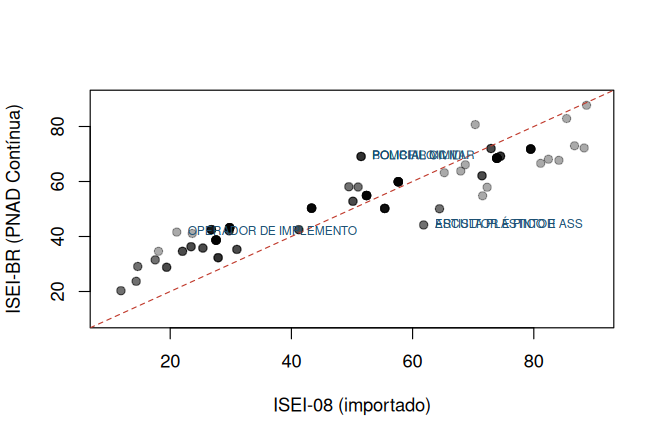

```r
d <- w[order(-abs(w$isei_br - w$isei08)), ]
plot(w$isei08, w$isei_br, pch = 19, col = "#00000055",
     xlab = "ISEI-08 (importado)", ylab = "ISEI-BR (PNAD Contínua)",
     xlim = c(10, 90), ylim = c(10, 90))
# a diagonal marca a igualdade de ESCORE, nao a de posicao: as duas escalas
# tem dispersoes diferentes, e a leitura correta vem logo abaixo
abline(0, 1, col = "#C0392B", lty = 2)
text(d$isei08[1:6], d$isei_br[1:6], substr(d$rotulo[1:6], 1, 22),
     pos = 4, cex = 0.65, col = "#1B4F72", xpd = NA)
```

A diagonal vermelha do gráfico é tentadora e engana. As duas escalas não têm a mesma dispersão: o ISEI-BR sai de um min–max sobre as células de estimação, e o seu desvio padrão nestas ocupações é bem menor que o do ISEI-08.

```r
c(isei08 = sd(w$isei08), isei_br = sd(w$isei_br))
```

```
#>   isei08  isei_br
#> 21.35294 14.49087
```

Numa escala mais estreita, o topo cai e a base sobe por construção. A conta que mostra o tamanho do problema é esta:

```r
z <- function(x) (x - mean(x)) / sd(x)
r <- cor(w$isei_br, w$isei08)
c(bruta         = cor(w$isei_br - w$isei08, w$isei08),
  padronizada   = cor(z(w$isei_br) - z(w$isei08), w$isei08),
  forcada_por_r = -sqrt((1 - r) / 2))
```

```
#>         bruta   padronizada forcada_por_r
#>    -0.8425687    -0.1731228    -0.1731228
```

A diferença **bruta** correlaciona-se a cerca de −0,84 com o próprio ISEI-08 — ler nela uma relocação substantiva é ler, em boa parte, de onde a ocupação partiu. Padronizar remove esse artefato, e é sobre a diferença padronizada que a leitura tem de ser feita.

Repare, porém, na terceira linha, porque ela impede uma leitura errada da segunda. A correlação padronizada **não some** — nem poderia. Para dois vetores padronizados com correlação `r`, vale a identidade

`cor(z1 - z2, z2) = -sqrt((1 - r) / 2)`

e com `r` = 0.94 ela dá exatamente o valor observado — não aproximadamente: até a última casa que o computador guarda. Não é uma medida: é aritmética, e é sempre negativa — regressão à média. Seria errado, portanto, ler o -0.173 residual como “o tanto de artefato que sobrou”, ou esperar que ele fosse zero caso a diferença fosse puramente substantiva. Com escalas iguais e esta correlação, ele seria esse número de qualquer jeito.

O que a padronização resolve é o artefato de **escala**, que era grande. O que ela não pode fazer é produzir uma medida ortogonal ao ponto de partida — e é por isso que a leitura abaixo vem acompanhada de uma conferência.

```r
w$d <- z(w$isei_br) - z(w$isei08)
sobem  <- head(w[order(-w$d), c("rotulo", "isei08", "isei_br")], 6)
descem <- head(w[order(w$d),  c("rotulo", "isei08", "isei_br")], 6)
rbind(sobem, descem)
```

```
#>                                              rotulo isei08 isei_br
#> 36                                   BOMBEIRO CIVIL  51.50    69.1
#> 101                                  POLICIAL CIVIL  51.50    69.1
#> 102                                POLICIAL MILITAR  51.50    69.1
#> 122                                BOMBEIRO MILITAR  51.50    69.1
#> 140                             DIRETOR DE EMPRESAS  70.34    80.7
#> 9                                            MÉDICO  88.70    87.7
#> 88                                ESCULTOR E PINTOR  61.82    44.2
#> 89                  ARTISTA PLÁSTICO E ASSEMELHADOS  61.82    44.2
#> 214 SACERDOTE OU MEMBRO DE ORDEM OU SEITA RELIGIOSA  71.55    54.8
#> 51                              CANTOR E COMPOSITOR  64.44    50.1
#> 52                                           MÚSICO  64.44    50.1
#> 104  PROFESSOR E INSTRUTOR DE FORMACAO PROFISSIONAL  72.30    57.9
```

As que mais sobem são as de segurança pública: policial civil e militar, bombeiro. São trabalhos que a régua importada põe no meio da tabela e que no Brasil pagam acima do que o escore internacional sugere. Ao lado deles aparecem o diretor de empresas e o médico — e é justamente isso que a comparação bruta escondia, porque ocupações de topo não têm para onde subir numa escala comprimida.

As que mais descem são as profissões artísticas, o clero e o ensino de arte: escultor, artista plástico, sacerdote, cantor, músico, professor de formação profissional. Veterinário e farmacêutico vêm logo atrás, em sétimo e oitavo. Credencial alta, remuneração modesta. É a mesma anomalia do cuidado vista pelo outro lado: a régua importada mede sobretudo credencial, e no Brasil credencial e remuneração andam mais separadas do que ela supõe.

A conferência prometida acima. O resíduo de uma regressão do ISEI-BR sobre o ISEI-08 é ortogonal ao ponto de partida **por construção** — não por sorte —, e por isso é o critério que não pode ser acusado de artefato:

```r
w$resid <- residuals(lm(isei_br ~ isei08, data = w))
c(sobem_iguais  = identical(head(w$rotulo[order(-w$d)], 6),
                            head(w$rotulo[order(-w$resid)], 6)),
  descem_mesmas = setequal(head(w$rotulo[order(w$d)], 6),
                           head(w$rotulo[order(w$resid)], 6)))
```

```
#>  sobem_iguais descem_mesmas
#>          TRUE          TRUE
```

As seis que sobem são as mesmas, na mesma ordem; as seis que descem são as mesmas, com o clero trocando de posição dentro do grupo. A leitura substantiva não depende de qual dos dois critérios se use, e é isso — não a correlação residual — que autoriza lê-la.

## O que esta vinheta não prova

O critério continua sendo o patrimônio de **candidatos**, que não são a população. Isso não mudou. A régua brasileira foi estimada na população e validada em candidatos, o que é melhor do que estimar e validar nos mesmos candidatos, mas não é o mesmo que validá-la na população.

Quatro coisas seguem em aberto, e convém dizê-las com a mesma clareza com que esta vinheta dizia, antes, que a régua não era brasileira.

A primeira é que a mediação não é completa. O procedimento de 1992 supõe que a ocupação carrega todo o efeito da escolaridade sobre a renda, e no Brasil ela carrega 58.4%. O resto é escolaridade que paga dentro da mesma ocupação. A régua registra esse número em vez de escondê-lo, mas registrá-lo não o resolve.

A segunda é que a régua é de um ano só, 2025, em valores nominais. Ela não forma série, e uma análise que atravesse décadas não pode usá-la como se formasse.

A terceira é que 242 das 590 linhas foram apuradas num grupo mais grosso que a própria ocupação, por falta de amostra. A coluna `nivel` diz quais, e quem depende de uma ocupação específica deve conferi-la antes.

A quarta é que a correlação no nível da candidatura, em `tse_dispersao_patrimonio`, existe só para o ISEI-88, porque a tabela de somatórios é indexada por faixas daquela régua. Refazê-la para a brasileira é trabalho de outra rodada.